# Data note: Edinburgh landlord register data analysis

Mark Livingston and Nick Bailey

April 2019

# Introduction

In this note, we examine a dataset obtained from the City of Edinburgh’s private landlord registration system. We explore the potential value of these data by comparing them with other data sources on private renting in the city. We also comment on what they tell us about the implementation of the landlord registration scheme.

Data were obtained from City of Edinburgh Council’s register of private landlords under a Freedom of Information (FoI) request in December 2017. The request was made on 07/09/2017 - request number 16177. It was initially rejected by the Council but accepted after an appeal. The legislation which created the statutory landlord registration system (the Anti-Social Behaviour (Scotland) Act 2004) explicitly prevents local authorities from publishing the entire contents of the register. This causes some authorities to believe that they are not permitted to share any part of the data contained in the register or to publish summary information or statistics from it. However, as we have argued in pursuing access to these data under FoI, publishing aggregated, anonymised extracts from the database is not probited by the legislation. Indeed, the *explicit* ban on full publication can be seen as an *implicit* recognition that partial or summary information can be published.

Similar Data Notes have been produced with extracts from the landlord registers for [Aberdeen](https://www.ubdc.ac.uk/media/1518/data-note-22017-landlord-register-aberdeen.pdf) and [Renfrewshire](https://www.ubdc.ac.uk/media/1421/data_note_prs_in_renfrew.pdf) councils.

# Census and survey data on the PRS in Edinburgh

Some data on the PRS in Edinburgh are available from the Census and from household surveys. The Census can provide detail for small areas or neighbourhoods but is now somewhat out of date while the surveys can only provide reliable estimates at local authority level.

At the 2011 Census, there where 224,240 households in Edinburgh, of which 49,980 (22.3%) were in the private rented sector (PRS). We can estimate changes since then using the Scottish Survey Core Questions (SSCQ) for 2012-16 (Figure 1). This shows a rise households number and in private renting, although the latter appears to have peaked in 2014. In 2016, there were an estimated 232,900 households in the city - an increase of 3.9% from 2011. The number of households in private renting rose to a peak of nearly 70,000 in 2014 but fell in subsequent years to 63,920 in 2016 (27.4%). That figure is still 28% higher than the Census estimate.

#### Figure 1: Private renting in Edinburgh - SSCQ 2012-16

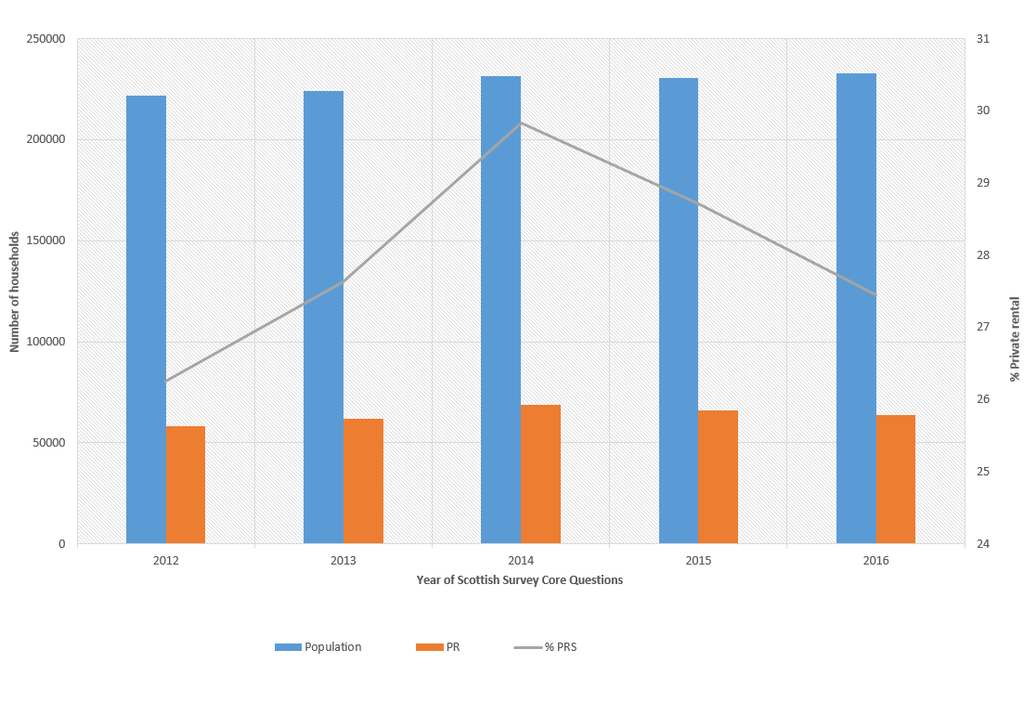

# Landlord register dataset

Data from the landlord register were provided as a .csv file, listing each unit postcode containing any registered properties and the number of registered properties in each. It should be noted that, where a property is owned by two or more individuals, each person is required to register separately. In this dataset, however, duplicate listings for the same property have been combined. This is different to the treatment in the Aberdeen data note where the data were provided as the number of listings in each postcode. The Renfrewshire dataset was different again as it contained all listings but also an anonymous identifier which let us see where there were multiple listings for a property. The Renfrewshire data note therefore gives some insights into the differences which result.

Various initial checks were carried out on the postcodes. All begin with “EH” as expected. All but one has the expected 7 or 8 characters. The exception had 9 characters including two spaces. We chose to assume that this could be corrected by removing the extra space. However, it is surprising that the system does not seem to check and prevent an obviously invalid postcode from being entered.

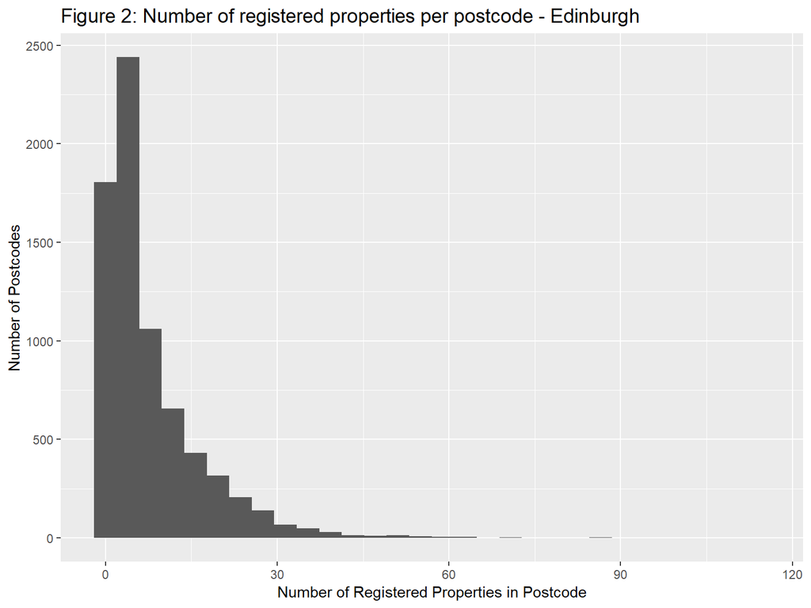

The number of registered properties is 85.4% of the estimated total for Edinburgh (using the SSCQ figure from 2016). As a first estimate, there appear to be 14.6% of properties not listed (around 9320 properties). If private renting in Edinburgh continued to fall in 2017 in line with the previous years, the registration rate would be slightly higher. On the other hand, this estimate of the registration rate may also be an overestimate since properties can be listed but not let (i.e. there may be more let properties not registered). Nevertheless, it suggests a very high coverage overall.

# Comparison of landlord register with Census

The great advantage of the landlord register data is that it provides detail down to the small area level. Here we aggregate data from unit postcodes to Datazones, and then use these to compare with Census data for the same units.

We do not expect a perfect fit between these data for two reasons. The first is the obvious difference in timing of around six years during which time the sector will have grown faster in some locations than others. The second is that we know that not all rented properties are registered, nor are all registered properties be rented as noted in the previous section. Nevertheless, given the apparently high rate of registration, we would expect a strong the relationship between the two.

To aggregate unit postcodes to Datazones, we use a lookup file. In this process, the lookup failed in just 18 cases - a very small fraction. These cases contained 27 properties. However, there are also a number of cases where the FOI entry matches to a postcode which is in a Datazone outside Edinburgh. This happens in 7 cases.

In the final dataset, there are 597 Datazones in Edinburgh in 2011. These contain 54566 registered properties. The number of Datazones with no registered properties is just 1. Figure 3 shows the distribution of properties per Datazone. The highest number of registered properties in a Datazone is 568.

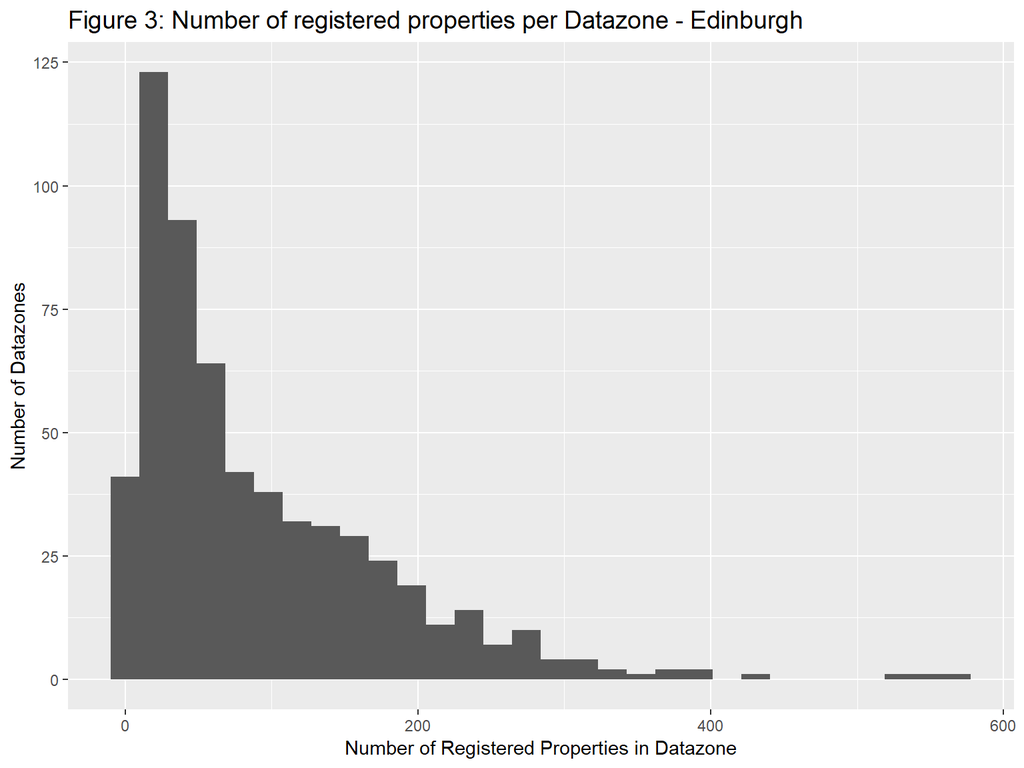

A scatterplot shows the relationship between the number of properties in the PRS according to the Census 2011 and the number of registered properties in 2017 (Figure 4). Overall, the correlation is very high (R = 0.92). The solid line is the line of equality while the dashed line shows the exected number of registered properties in each case (given the number of registered properties compared with the number recorded by the Census). There are a few points some way below the line but more some way above it, suggesting that these are locations where private renting has been growing most strongly.

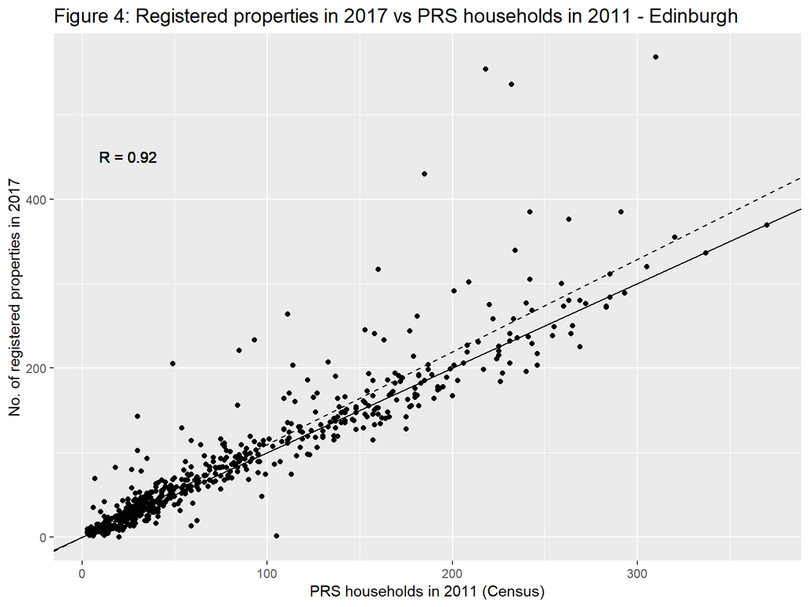

#### Figure 5: Households in PRS - 2011 census

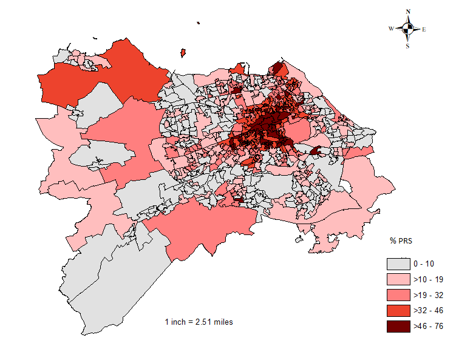

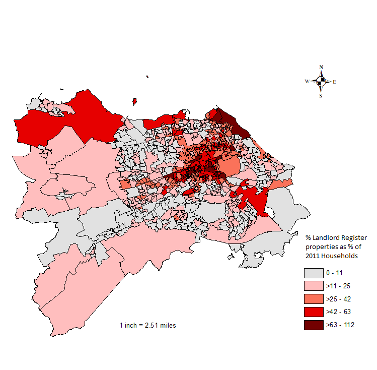

## Access to data and code

The landlord register datasets for Edinburgh and Aberdeen can be accessed from the UBDC data portal (http://ubdc.gla.ac.uk/dataset). The data and code used to produce this datanote can be access from Github at https://github.com/nick-bailey/Edinburgh-landlord-registration-data.